# Introdução ao web scraping aplicado a índices de preços - Dia 2

Lincoln Teixeira da Silva e Plinio Marcos Leal dos Santos

23/02/2022

## 1 - Configurar Selenium no R.

Para utilizar o pacote RSelenium que promove uma interação entre o R e o navegador devemos ter instalado alguns arquivos e declarar para o R onde eles estão.

## 1.1 - Download Selenium e Chromedriver

- [Selenium Server Standalone Binary](http://selenium-release.storage.googleapis.com/index.html?path=4.0/)
- [ChromeDriver](https://chromedriver.chromium.org/downloads) - conforme versões do navegador e sistema operacional.

## 1.2 - Declarar Selenium e Chromedriver

Precisamos declarar para o R onde estão os arquivos que foram baixados para o funcionamento do pacote RSelenium que promoverá a interação entre o R e o browser.

```r
setwd("...") # Inserir caminho
system("java -jar selenium-server-standalone-4.0.0-alpha-1.jar", wait = FALSE) # Declara selenium
system("chromedriver.exe", wait = FALSE) # Declara chromedriver
```

```
## [1] 0
```

```
## [1] 0
```

## 2 - Estudo de caso - Latam Airlines

Utilizaremos o site da Latam Airlines com sítio no Chile. A Latam é uma das maiores empresas de aviação da América Latina. O sítio da Latam no Chile foi escolhido aleatoriamente dentre os possíveis de língua espanhola.

Armazenar o link no objeto *link*.

```r
link = "https://www.latamairlines.com/cl/es"
```

Carregar pacotes que serão utilizados na extração, limpeza e organização dos dados.

```r
library(RSelenium)
library(tidyverse)
library(lubridate)
```

### 2.1 - Abrir o navegador e ir para a página desejada

Após carregar os pacotes e informar para o R onde estão os arquivos do Selenium Server e do Chromedriver podemos utililizar as funções do pacote RSelenium para interagir com a página.

```r
remDr <- remoteDriver(remoteServerAddr = "localhost",
                      browserName = "chrome") # Inicia o driver
remDr$open() # Abre navegador/browser
```

[output not shown]

[output cut: 35 more lines]

[output not shown]

```r
remDr$navigate(link) # Navega pelo link
remDr$maxWindowSize() # Maximiza a janela do navegador
```

### 2.2 - Clicar em aceitar cookies ou continuar em Latam Chile.

A página principal ao abrir pode surgir com duas mensagens conforme ilustrado na figura 1.

- 1. Para residentes no Chile uma mensagem para aceitar cookies.
- 2. Para não residentes do Chile há uma pergunta se deseja continuar na página da LATAM Chile.

[figure not shown]

Figura 1: Diferença entre residentes no Chile e não residentes

Devemos clicar em aceitar cookies ou continuar em Latam Chile. A identificação de nós acontece conforme visto no dia 1. Podemos usar o Selector gadget para encontrar esses nós.

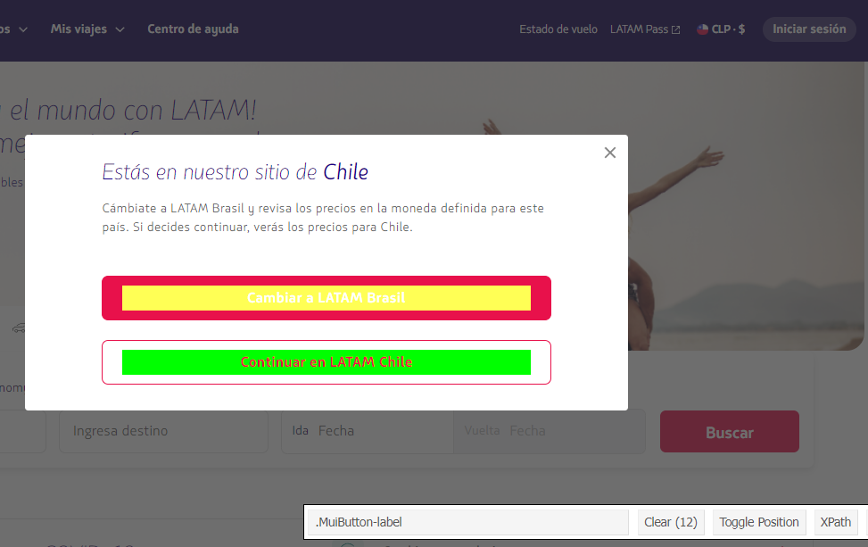

Porém os comandos para extrair os nós são um pouco diferentes.

```r
web_elements <- remDr$findElements(using = 'css',
                                   value = ".MuiButton-label") # Procura elementos
lapply(web_elements, function(x){x$getElementText()}) %>%  # Extrai texto dos elementos
      unlist
```

```
##  [1] ""                         ""
##  [3] ""                         ""
##  [5] ""                         ""
##  [7] ""                         ""
##  [9] ""                         ""
## [11] "Cambiar a LATAM Brasil"   "Continuar en LATAM Chile"
```

O objetivo é **clicar** no elemento com o nome *Continuar en LATAM Chile*. Portanto, devemos clicar no último elemento da lista utilizando a função **clickElement**.

```r
web_elements[[length(web_elements)]]$clickElement() # Clica no último elemento encontrado
```

### 2.3 - Selecionar quantidade de passageiros

Podemos, por exemplo, querer selecionar vôos com mais de 1 adulto ou incluir crianças e/ou bebês. Novamente, devemos interagir com a página e clicar em botões que façam esse tipo de alteração. O elemento para abrir a opção para incluir passageiros é mostrado na Figura 3. O objetivo é *clicar* no elemento, portanto após encontrar o nó devemos utilizar a função **clickElement**

[figure not shown]

Figura 3: Clica para incluir passageiro

```r
web_element <- remDr$findElement(using = 'css',
                                 value = "#btnAddPassengerCTA") # Procura botão passageiros
web_element$clickElement() # Clica no botão de passageiros
Sys.sleep(0.5) # Aguarda 0.5 segundos
```

Para adicionar adulto o elemento é diferente conforme ilustrado na Figura 4. Além disso, nem sempre será possível utilizar o Selector gadget para selecionar um elemento. A opção *Inspecionar* pode ser a solução para encontrar o nó. Após encontrar o nó clicamos no elemento para incluir um passageiro adulto.

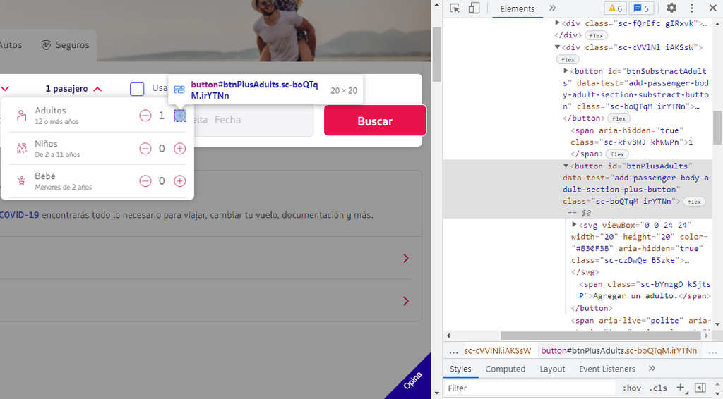

Figura 4: Clica para incluir passageiro

```r
web_element <- remDr$findElement(using = 'id',
                                 value = "btnPlusAdults") # Procura botão que adiciona passageiro adulto
web_element$clickElement() # Clica no elemento
```

Fecha opção de passageiros conforme visto anteriormente.

```r
web_element <- remDr$findElement(using = 'id',
                                 value = "btnAddPassengerCTA") # Procura botão passageiros
web_element$clickElement() # Clica no elemento
```

### 2.4 - Inserir a cidade/aeroporto de origem

Para inserir o aeroporto de origem devemos:

1. Encontrar o nó da caixa para inserir a origem e clicar no elemento.
2. Inserir o texto com a origem na caixa
3. Encontrar o nó da opção que vai aparecer após escrever o texto da origem. Clicar no elemento.

[figure not shown]

Figura 5: Inserir Origem

```r
webElem <- remDr$findElement(using = 'css',
                             value = "#txtInputOrigin_field") # Procura botão para incluir origem
webElem$clickElement() # Clica no elemento
cidade_origem = "Santiago de Chile, SCL - Chile" # Cidade de origem
webElem$sendKeysToElement(list(cidade_origem)) # Insere cidade de origem no campo ativo.
webElem <- remDr$findElement(using = 'css',
                             value = "#btnItemAutoComplete_0") # Procura opções após inserir texto da origem
webElem$clickElement() # Clica no elemento
```

### 2.5 - Inserir a cidade/aeroporto de destino

Depois de inserir a origem o cursor vai para o botão de destino. Contudo, não é possível inserir o texto do aeroporto de origem. Devemos clicar em algum lugar da página fora da caixa de *Vuelos* e depois inserir o destino de forma similar ao que foi feito para inserir a origem.

```r
webElem <- remDr$findElement(using = 'css',
                             value = ".sc-kaCJFH") # Procura elemento sair da caixa de rota
webElem$clickElement() # Clica no elemento
Sys.sleep(0.5) # Aguarda 0.5 segundos
```

Similar ao que foi feito para a origem, para inserir o aeroporto de destino devemos:

1. Encontrar o nó da caixa para inserir o destino e clicar no elemento.
2. Inserir o texto com a origem na caixa
3. Encontrar o nó da opção que vai aparecer após escrever o texto do destino Clicar no elemento.

[figure not shown]

Figura 6: Inserir Destino

```r
webElem <- remDr$findElement(using = 'css',
                             value = "#txtInputDestination_field") # Procura botão para incluir destino
webElem$clickElement() # Clica no elemento
cidade_destino = "Rio de Janeiro, RIO - Brasil" # Cidade de destino
webElem$sendKeysToElement(list(cidade_destino)) # Insere cidade de origem no campo ativo.
webElem <- remDr$findElement(using = 'id',
                             value = "btnItemAutoComplete_0") # Procura opções após inserir texto do destino
webElem$clickElement() # Clica no elemento
```

### 2.6 - Inserir datas de ida e volta.

Para inserir as datas de ida e volta devemos interagir com o site clicando nos elementos desejados.

1. Clicar no nó da caixa para inserir a data de ida e clicar no elemento.
2. Clicar na data de ida
3. Clicar na data de volta

O nó do campo de ida está ilustrado na Figura 7. Após encontrar o nó, clicamos no elemento para abrir as opções de datas disponíveis.

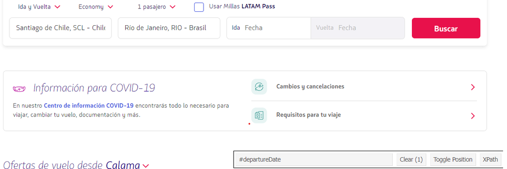

Figura 7: Inserir Datas

Para escolher a data de ida e volta o processo é um pouco diferente do que vimos até agora. Em geral, escolhemos elementos utlizando nós de *classe* e *id*, mas para encontrar o elemento das datas teremos que escolher um nó *aria-label* e informar que o texto contido ali dentro seja um texto pré-definido. A Figura 8 mostra o nó da data 5 de Março de 2022. Devemos fazer com que o texto do nó *aria-label* seja o texto ‘Elija sábado, 5 de marzo de 2022 como su fecha de ida. Está disponible.’ Após encontrar o nó devemos clicar no elemento para escolher a data de ida.

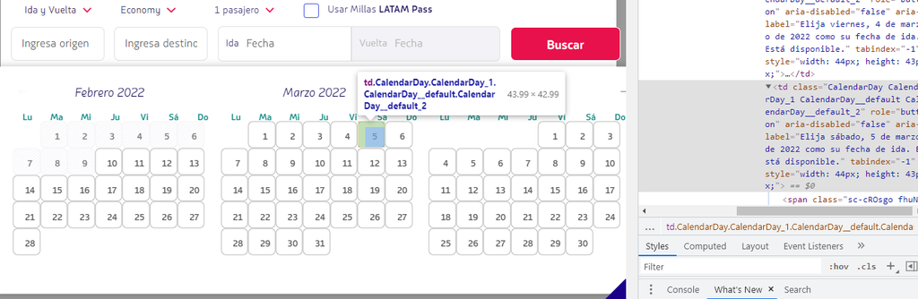

Figura 8: Escolher data de ida e volta

O procedimento para volta é análogo e o texto é praticamento o mesmo.

```r
webElem <- remDr$findElement(using = 'css', value = "#departureDate") # Procura botão para incluir data
webElem$clickElement() # Clica no elemento
Sys.sleep(1) # Aguarda 1 segundo
departureDate = "Elija sábado, 5 de marzo de 2022 como su fecha de ida. Está disponible." # Data ida 5 de março de 2022
webElem <- remDr$findElement(using = 'css',
                             value = paste0("[aria-label='", departureDate, "']")) # Procura data onde o texto equivale ao objeto departureDate
webElem$clickElement() # Clica no elemento
returnDate = "Elija sábado, 12 de marzo de 2022 como fecha de vuelta. Está disponible." # Data volta 12 de março de 2022
webElem <- remDr$findElement(using = 'css',
                             value = paste0("[aria-label='", returnDate, "']")) # Procura data onde o texto equivale ao objeto returnDate
webElem$clickElement() # Clica no elemento
```

### 2.7 - Clicar em buscar

Após inserir as configurações do vôo de preferência, devemos clicar no botão buscar para encontrar as opções de vôos e extrair os dados de interesse. Nota-se que até o momento utilizamos o Selenium para interagir com o site somente clicando em elementos e inserindo textos.

```r
webElem <- remDr$findElement(using = 'id',
                             value = "btnSearchCTA") # Procura elemento do botão buscar
webElem$clickElement() # Clica no elemento
Sys.sleep(5) # Esperar um tempo para a página carregar
```

### 2.8 - Extração dos dados dos vôos.

Até então, estávamos utilizando o Selenium para interagir com a página, clicar em elementos e inserir textos. Agora iremos extrair dados da página. O processo para encontrar os nós é o mesmo visto com o pacote *rvest*, porém as funções para extração do texto dos elementos tem nomes e saídas um pouco diferentes. Na verdade, um exemplo similar já foi mostrado na hora de selecionar o elemento correto para aceitar cookies ou permanecer no sítio da Latam Chile.

O processo para extrair os dados dos vôos de ida e volta são iguais. Nesse caso é interessante criar uma **função** com esse processo para não tornar o código repetitivo.

Após clicar no botão buscar para encontrar os vôos, o site exibe todos os vôos possíveis de ida. Hora de ida e chegada, aeroporto de ida e chegada, duração do vôo, número de paradas. Essas informações podem ser extraídas encontrando os nós de cada um deles e extraindo seu texto assim que a página é carregada.

Contudo, a página não exibe (ainda) as opções dos preços por tarifas. Para descobrir essas informações devemos clicar em cada um dos vôos para extrair essa informação.

Em resumo, a função a seguir extrairá:

- 1. Total de vôos
- 2. Aeroportos de ida e chegada
- 3. Horas de ida e chegada
- 4. Duração do Vôo
- 5. Número de paradas
- 6. Clica em cada um dos vôos disponíveis e extrai:
  - 1. Tarifa
  - 2. Preço
- 7. Armazena em um dataframe

```r
dados_voo <- function(){
  # Total de voos
  web_elements <- remDr$findElements(using = 'css',
                                     value = ".displayAmount") # Procura elemento de preços
  n_voos = lapply(web_elements, function(x){x$getElementText()}) %>%
      unlist %>% # Extrai texto dos elementos encontrados
    str_subset("CLP") %>%
    length # Comprimento do vetor


  # Informação do voo
  web_elements = remDr$findElements(using = 'css',
                                    value = ".flight-information") # Procura elemento com informação dos vôos
  flight_info = lapply(web_elements, function(x){x$getElementText()}) %>%
    unlist %>% # Extrai texto dos elementos encontrados
    str_remove_all("\n") # Exclui quebra de linhas

  # Sigla Aeroporto de saída
  aer_ida <- flight_info %>% # Com o objeto flight_info
    str_extract('[A-Z]+') %>% # Extrai somente as letras maiúsculas
    .[seq(1, length(.), by = 2)] # Extrai os elementos ímpares do vetor

  # Sigla Aeroporto de chegada
  aer_chegada <- flight_info %>% # Com o objeto flight_info
    str_extract('[A-Z]+') %>% # Extrai somente as letras maiúsculas
    .[seq(2, length(.), by = 2)] # Extrai os elementos pares do vetor

  # Hora de saída
  hora_ida = flight_info %>% # Com o objeto flight_info
    str_extract('[^A-Z]+') %>% # Extrai tudo que não seja letras maiúsculas
    .[seq(1, length(.), by = 2)] # Extrai os elementos ímpares do vetor

  # Hora de chegada
  hora_chegada = flight_info %>% # Com o objeto flight_info
    str_extract('[^A-Z]+') %>% # Extrai tudo que não seja letras maiúsculas
    .[seq(2, length(.), by = 2)] # Extrai os elementos pares do vetor

  # Duracao do voo
  web_elements = remDr$findElements(using = 'css',
                                    value = ".flight-duration .hhrBNA") # Procura elemento com informação dos vôos
  duracao = lapply(web_elements, function(x){x$getElementText()}) %>%
    unlist # Extrai texto dos elementos encontrados

  duracao_hora <- str_extract(duracao, '[0-9]+ h') %>% # Extrai somente a parte com número seguido de ' h'
                      str_remove_all(' h') %>% # Exclui ' h'
    str_pad(width = 2, pad = "0", side = "left") # Inclui 0 à esquerda caso o número tenha somente um algarismo

  duracao_min <- ifelse(str_detect(duracao , 'min$',  negate = TRUE), paste0(duracao, ' 0 min'), duracao) %>% # Se não existe 'min' no texto, inclui ' 0 min'
    str_extract('[0-9]+ min') %>% # Extrai somente a parte com número seguido de ' min'
    str_remove_all(' min') %>% # Exclui ' min'
    str_pad(width = 2, pad = "0", side = "left") # Inclui 0 à esquerda caso o número tenha somente um algarismo

  duracao_formatado <- paste(duracao_hora, duracao_min, sep = ":") # Junta hora e minuto separando por ":"


  # Número de paradas
  web_elements = remDr$findElements(using = 'css',
                                    value = ".lgvePP") # Procura elemento com informação dos vôos
  n_paradas = lapply(web_elements, function(x){x$getElementText()}) %>%
    unlist %>% # Extrai texto dos elementos encontrados
    str_extract('[0-9]+') %>%  # Extrai somente números
    as.numeric() %>% # Transforma em numérico
    ifelse(is.na(.), 0, .) # Se há NA, transforma em 0 senão mantém o valor antigo.

  precos <- list() # Cria objeto do tipo lista - precos
  tarifa <- list() # Cria objeto do tipo lista - tarifa
  for(i in 1:n_voos){ # Loop de 1 até total de voos
    price_node <- paste0("#WrapperCardFlight", i-1) # Descobre nome do nó que abre determinado tipo de voo
    web_elements <- remDr$findElement(using = 'css',
                                      value = price_node) # Procura card do voo
    web_elements$clickElement() # Clica no elemento
    web_elements = remDr$findElements(using = 'css',
                               value = paste0(price_node, " .displayAmount")) # Após clicar num vôo, extrai os preços somente dentro do vôo
    precos <- c(precos, # Concatena a lista de precos + nova lista
                list(lapply(web_elements, function(x){x$getElementText()}) %>%
                        unlist %>% # Extrai texto dos elementos encontrados
                        str_remove_all("CLP ") %>% # Retirar "CLP "
                        str_remove_all("\\.") %>% # Retirar pontos
                        as.numeric() # Transformar em numérico
                )

    )
    web_elements <- remDr$findElements(using = 'css',
                                       value = paste0(price_node, " .bwousA")) # Procura elemento de tarifa
    tarifa1 <-  lapply(web_elements, function(x){x$getElementText()}) %>%
      unlist # Extrai texto dos elementos encontrados
    web_elements <- remDr$findElements(using = 'css',
                                       value = paste0(price_node, " .ijdLad")) # elemento de tarifa especial
    tarifa2 <-  lapply(web_elements, function(x){x$getElementText()}) %>%
      unlist # Extrai texto dos elementos encontrados
    if(!is.null(tarifa2)){
      tarifa2 <- gsub("\n", "", tarifa2) # Se tarifa especial existe, remove o caracter '\n'
    }
    tarifa  <- c(tarifa,
                 list(c(tarifa1, tarifa2)) # Concatena tarifas especiais em uma lista.
                )

    # Fecha opções de um vôo específico
    web_element <- remDr$findElement(using = 'css',
                                     value = ".MuiButton-label") # Procura elemento para fechar o vôo selecionado
    web_element$clickElement() # Clica no elemento
  }

  # Retorna dataframe criado com os dados extraídos.
  # - Aeroporto de ida
  # - Aeroporto de chegada
  # - Hora de partida
  # - Hora de chegada
  # - Duração
  # - Número de paradas
  # - Preços
  # - Tipo de tarifa
  # - Data da coleta
  # - Hora da coleta

  dframe = data.frame()
  for(i in 1:length(aer_ida)){
    dframe = rbind(dframe,
                   data.frame("aero_ida" = aer_ida[i], "aero_llegada" = aer_chegada[i],
                              "hora_ida" = hora_ida[i], "hora_llegada" = hora_chegada[i],
                              "duracao" = duracao_formatado[i], "paradas" = n_paradas[i],
                              "tarifa" = unlist(tarifa[i]), "precios" = unlist(precos[i]),
                              "dia" = today(),
                              "hora" = format(now(), "%H:%M:%S")))
  }
  return(dframe)
}
```

Utilizar a função *dados_voo* para a extração dos dados dos vôos de ida.

```r
ida = dados_voo() # Coleta dados de ida
```

Para exibir as informações dos vôos de volta devemos escolher algum vôo de ida. Primeiro selecionamos o primeiro vôo.

```r
web_element <- remDr$findElement(using = 'css', value = ".displayAmount") # Procura elemento do primeiro voo
web_element$clickElement() # Clica no elemento
Sys.sleep(1) # Aguarda 1 segundo
```

Depois clicamos na primeira opção do vôo selecionado anteriormente.

```r
web_element <- remDr$findElement(using = 'id',
                                 value = "WrapperBundleCardbundle-detail-00") # Procura elemento da primeira opção disponível
web_element$clickElement() # Clica no elemento
Sys.sleep(10) # Aguardar 10 segundos para a página carregar
```

Espera página carregar

Utilizar a função *dados_voo* para a extração dos dados dos vôos de volta.

```r
volta = dados_voo() # Coleta dados de ida
```

### 2.9 - Fecha o navegador

```r
remDr$close() # Fecha browser
```

### 2.10 - Ver dados extraídos dos vôos

Ida

```r
DT::datatable(ida)
```

|  | aero_ida | aero_llegada | hora_ida | hora_llegada | duracao | paradas | tarifa | precios | dia | hora |
| --- | --- | --- | --- | --- | --- | --- | --- | --- | --- | --- |
| 1 | SCL | GIG | 13:45 | 17:50 | 04:05 | 0 | basic | 161112 | 2022-02-11 | 15:41:19 |
| 2 | SCL | GIG | 13:45 | 17:50 | 04:05 | 0 | light | 196458 | 2022-02-11 | 15:41:19 |
| 3 | SCL | GIG | 13:45 | 17:50 | 04:05 | 0 | plus | 217008 | 2022-02-11 | 15:41:19 |
| 4 | SCL | SDU | 7:55 | 16:55 | 09:00 | 1 | basic | 207833 | 2022-02-11 | 15:41:19 |
| 5 | SCL | SDU | 7:55 | 16:55 | 09:00 | 1 | light | 248111 | 2022-02-11 | 15:41:19 |
| 6 | SCL | SDU | 7:55 | 16:55 | 09:00 | 1 | plus | 271949 | 2022-02-11 | 15:41:19 |
| 7 | SCL | SDU | 7:55 | 16:55 | 09:00 | 1 | top -Premium Business | 749531 | 2022-02-11 | 15:41:19 |
| 8 | SCL | SDU | 7:55 | 17:10 | 09:15 | 1 | basic | 166649 | 2022-02-11 | 15:41:19 |
| 9 | SCL | SDU | 7:55 | 17:10 | 09:15 | 1 | light | 201995 | 2022-02-11 | 15:41:19 |
| 10 | SCL | SDU | 7:55 | 17:10 | 09:15 | 1 | plus | 222545 | 2022-02-11 | 15:41:19 |

[output cut: 82 more lines]

Volta

```r
DT::datatable(volta)
```

|  | aero_ida | aero_llegada | hora_ida | hora_llegada | duracao | paradas | tarifa | precios | dia | hora |
| --- | --- | --- | --- | --- | --- | --- | --- | --- | --- | --- |
| 1 | GIG | SCL | 18:50 | 23:30 | 04:40 | 0 | basic | 166748 | 2022-02-11 | 15:42:07 |
| 2 | GIG | SCL | 18:50 | 23:30 | 04:40 | 0 | light | 203738 | 2022-02-11 | 15:42:07 |
| 3 | GIG | SCL | 18:50 | 23:30 | 04:40 | 0 | plus | 225932 | 2022-02-11 | 15:42:07 |
| 4 | GIG | SCL | 18:50 | 23:30 | 04:40 | 0 | top | 269498 | 2022-02-11 | 15:42:07 |
| 5 | GIG | SCL | 4:35 | 11:55 | 07:20 | 1 | basic | 196964 | 2022-02-11 | 15:42:07 |
| 6 | GIG | SCL | 4:35 | 11:55 | 07:20 | 1 | light | 237242 | 2022-02-11 | 15:42:07 |
| 7 | GIG | SCL | 4:35 | 11:55 | 07:20 | 1 | plus | 261080 | 2022-02-11 | 15:42:07 |
| 8 | GIG | SCL | 4:35 | 11:55 | 07:20 | 1 | plus -Premium Business | 286562 | 2022-02-11 | 15:42:07 |
| 9 | GIG | SCL | 4:35 | 16:45 | 12:10 | 1 | basic | 128738 | 2022-02-11 | 15:42:07 |
| 10 | GIG | SCL | 4:35 | 16:45 | 12:10 | 1 | light | 159152 | 2022-02-11 | 15:42:07 |

[output cut: 87 more lines]

Visualização gráfica da distribuição de preços por tarifa e número de paradas para ambos os trechos

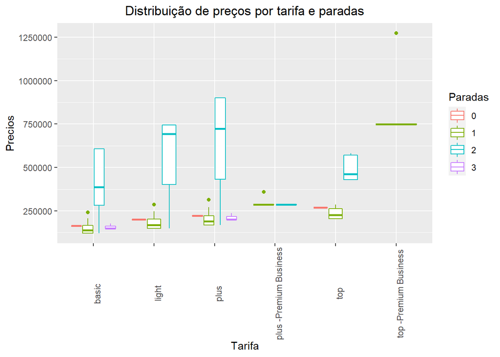

```r
rbind(ida, volta) %>%
  ggplot(aes(x = tarifa, y = precios, col = as.factor(paradas)))+
    geom_boxplot() +
    theme(axis.text.x = element_text(angle = 90), plot.title = element_text(hjust = 0.5)) +
    labs(x = 'Tarifa', y = 'Precios', title = 'Distribuição de preços por tarifa e paradas') +
    guides(col = guide_legend(title = "Paradas"))
```